# E4-1-2-1

```python
%matplotlib inline
import matplotlib.pyplot as plt
plt.style.use('seaborn-whitegrid')
import numpy as np
```

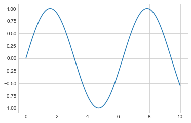

```python
fig = plt.figure()
ax = plt.axes()

x = np.linspace(0, 10, 1000)
ax.plot(x, np.sin(x));
```

## 調整圖的線條顏色和樣式

`plt.plot（）`函數接受可用於指定線條顏色和樣式參數的其他參數。 要調整顏色，可以使用`color`關鍵字，該關鍵字接受表示幾乎任何可以想像的顏色的字串參數。 顏色可以通過多種方式指定：

# 顏色

這可能是Matplotlib中最重要的詞彙。 鑒於Matplotlib是一個繪圖庫，顏色與圖中繪製的所有內容相關聯。

### Colornames

首先，顏色可以作為字串給出。對於非常基本的顏色，可以使用一個字母來：

- b：藍色
- g：綠色
- r：紅色
- c：青色
- 米：洋紅色
- y：黃色
- k：黑色
- w：白色

允許使用的其他顏色名稱是HTML / CSS顏色名稱，例如“burlywood”和“chartreuse”。請參閱140種顏色名稱的[完整列表]（https://www.w3schools.com/Colors/colors_names.asp）。

Matplotlib支持由''xkcd：'`預先設置的[xkcd顏色名稱]（https://xkcd.com/color/rgb/）。

Matplotlib也理解`{'tab：blue'，'tab：orange'，'tab：green'，'tab：red'，'tab：purple'，'tab：brown'，'tab：pink'，'tab： grey'，'tab：olive'，'tab：cyan'}`，它們是'T10'分類調色板中的Tableau顏色（和默認顏色迴圈）;

### 十六進位值

也可以通過提供HTML / CSS十六進位字串來指定顏色，例如藍色的“＃0000FF”。為v2.0添加了對可選alpha通道的支持。

### 256灰階

通過傳遞0到1之間的數位的字串表示（包括0和1），可以給出灰階而不是顏色。 `'0.0'是黑色，而''1.0'是白色。 ''0.75'將呈淺灰色。

### 迴圈引用

隨著來自許多可用樣式的更漂亮的色彩迴圈的出現，使用者需要一種方式來引用樣式中的那些顏色而不明確知道它們是什麼。因此，在v2.0中，添加了引用顏色迴圈的前10次反覆運算的能力。無論何時可以指定顏色，您都可以提供2個字元的“C＃”字串。因此，'C0'將是第一種顏色，'C1'將是第二種顏色，依此類推，直到'C9'。

### RGB [A]元組

您可能會遇到以前指定顏色的方法不起作用的情況。當所有其他方法都失敗時，matplotlib的通用顏色語言是RGB [A]元組。這是[0,1]範圍內的“紅色”，“綠色”，“藍色”，有時是“Alpha”元組的浮點數。一個意味著該通道的完全飽和，因此紅色RGBA元組將是“（1.0,0.0,0.0,1.0）”，而部分透明的綠色RGBA元組將是“（0.0,1.0,0.0,0.75）”。文檔通常會指定它是否接受RGB或RGBA元組。有時，多種顏色需要一個元組清單，在這種情況下甚至可以提供Nx3或Nx4 numpy陣列。

在諸如`plot（）`和`scatter（）`之類的函數中，雖然看起來它們可以採用顏色規範，但它們真正需要的是“格式規範”，其中包括顏色作為格式的一部分。不幸的是，這樣的規範只是字串，因此這些參數不支持RGB [A]元組（但你仍然可以傳遞RGB [A]元組用於“顏色”參數）。

通常情況下，“alpha”有一個單獨的參數，您可以指定顏色。 “alpha”的值通常優先於RGBA元組中的alpha值。這種不一致並沒有簡單的方法。

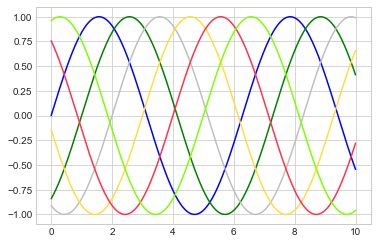

```python
plt.plot(x, np.sin(x - 0), color='blue')        # 利用name指定顏色
plt.plot(x, np.sin(x - 1), color='g')           # 利用簡短顏色碼(rgbcmyk)
plt.plot(x, np.sin(x - 2), color='0.75')        # 灰階(Grayscale)介於0與1之間
plt.plot(x, np.sin(x - 3), color='#FFDD44')     # 利用十六進位碼 (RRGGBB from 00 to FF)
plt.plot(x, np.sin(x - 4), color=(1.0,0.2,0.3)) # 利用RGB元組, 三原色的值都是從0到1
plt.plot(x, np.sin(x - 5), color='chartreuse'); # 也支援所有HTML顏色名稱
```

如果未指定顏色，Matplotlib將自動迴圈顯示多行的一組默認顏色。

同樣，可以使用`linestyle`關鍵字調整線條樣式：

# Linestyles

線條樣式與顏色一樣常用。 有一些預定義的線條樣式可供使用。

[output not shown]

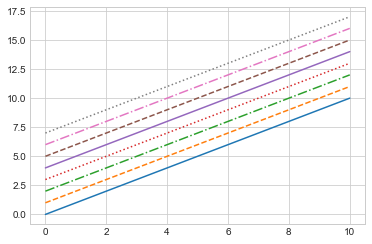

```python
plt.plot(x, x + 0, linestyle='solid')
plt.plot(x, x + 1, linestyle='dashed')
plt.plot(x, x + 2, linestyle='dashdot')
plt.plot(x, x + 3, linestyle='dotted');

# For short, you can use the following codes:
plt.plot(x, x + 4, linestyle='-')  # solid
plt.plot(x, x + 5, linestyle='--') # dashed
plt.plot(x, x + 6, linestyle='-.') # dashdot
plt.plot(x, x + 7, linestyle=':');  # dotted
```

這些`linestyle`和`color`代碼也可以合併為`plt.plot（）`函數的非關鍵字參數：

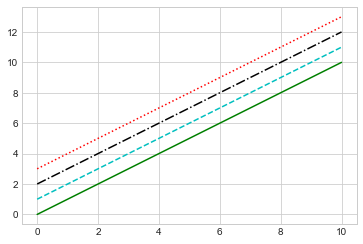

```python
plt.plot(x, x + 0, '-g')  # solid green
plt.plot(x, x + 1, '--c') # dashed cyan
plt.plot(x, x + 2, '-.k') # dashdot black
plt.plot(x, x + 3, ':r');  # dotted red
```

這些單字元顏色代碼反映了RGB（紅色/綠色/藍色）和CMYK（青色/品紅色/黃色/黑色/黑色）顏色系統中的標準縮寫，通常用於數位彩色圖形。

# 標記

[標記]常用於[`plot（）`]和[`scatter（）`]圖，但也出現在其他地方。有許多可用的標記，甚至可以指定自訂標記。

| 標記 | 描述 |  | 標記 | 描述 |  | 標記 | 描述 |  | 標記 | 描述 |
| --- | --- | --- | --- | --- | --- | --- | --- | --- | --- | --- |
| "." | point |  | "+" | plus |  | "," | pixel |  | "x" | cross |
| "o" | circle |  | "D" | diamond |  | "d" | thin_diamond |  |  |  |
| "8" | octagon |  | "s" | square |  | "p" | pentagon |  | "*" | star |
| "\|" | vertical line |  | "_" | horizontal line |  | "h" | hexagon1 |  | "H" | hexagon2 |
| 0 | tickleft |  | 4 | caretleft |  | "<" | triangle_left |  | "3" | tri_left |
| 1 | tickright |  | 5 | caretright |  | ">" | triangle_right |  | "4" | tri_right |
| 2 | tickup |  | 6 | caretup |  | "^" | triangle_up |  | "2" | tri_up |
| 3 | tickdown |  | 7 | caretdown |  | "v" | triangle_down |  | "1" | tri_down |
| "None" | nothing |  | `None` | default |  | " " | nothing |  | "" | nothing |

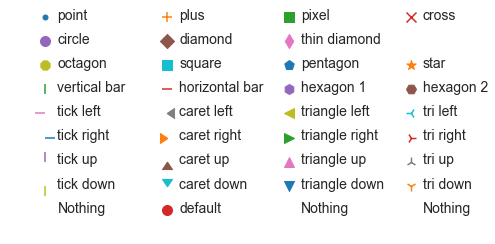

```python
xs, ys = np.mgrid[:4, 9:0:-1]
markers = [".", "+", ",", "x", "o", "D", "d", "", "8", "s", "p", "*", "|", "_", "h", "H", 0, 4, "<", "3",
           1, 5, ">", "4", 2, 6, "^", "2", 3, 7, "v", "1", "None", None, " ", ""]
descripts = ["point", "plus", "pixel", "cross", "circle", "diamond", "thin diamond", "",
             "octagon", "square", "pentagon", "star", "vertical bar", "horizontal bar", "hexagon 1", "hexagon 2",
             "tick left", "caret left", "triangle left", "tri left", "tick right", "caret right", "triangle right", "tri right",
             "tick up", "caret up", "triangle up", "tri up", "tick down", "caret down", "triangle down", "tri down",
             "Nothing", "default", "Nothing", "Nothing"]
fig, ax = plt.subplots(1, 1, figsize=(7.5, 4))
for x, y, m, d in zip(xs.T.flat, ys.T.flat, markers, descripts):
    ax.scatter(x, y, marker=m, s=100)
    ax.text(x + 0.1, y - 0.1, d, size=14)
ax.set_axis_off()
plt.show()
```

# 繪圖屬性

可以修改許多屬以製作任何繪圖，使線條和標記適合您的需要。 對於[`plt.plot（）`]，可以在單個字串中混合顏色，線條樣式和標記的規範。

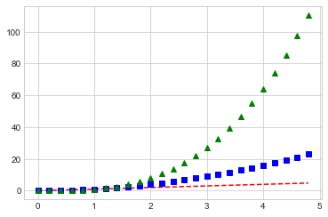

```python
t = np.arange(0., 5., 0.2)
# red dashes, blue squares and green triangles
plt.plot(t, t, 'r--', t, t**2, 'bs', t, t**3, 'g^')
plt.show()
```

| Property | Value Type |
| --- | --- |
| alpha | float |
| color or c | any matplotlib color |
| dash_capstyle | ['butt', 'round' 'projecting'] |
| dash_joinstyle | ['miter' 'round' 'bevel'] |
| dashes | sequence of on/off ink in points |
| drawstyle | [ ‘default’ ‘steps’ ‘steps-pre’ |
|  | ‘steps-mid’ ‘steps-post’ ] |
| linestyle or ls | [ '-' '--' '-.' ':' 'None' ' ' ''] |
|  | and any drawstyle in combination with a |
|  | linestyle, e.g. 'steps--'. |
| linewidth or lw | float value in points |
| marker | [ 0 1 2 3 4 5 6 7 'o' 'd' 'D' 'h' 'H' |
|  | '' 'None' ' ' `None` '8' 'p' ',' |
|  | '+' 'x' '.' 's' '*' '_' '\|' |
|  | '1' '2' '3' '4' 'v' '<' '>' '^' ] |
| markeredgecolor or mec | any matplotlib color |
| markeredgewidth or mew | float value in points |
| markerfacecolor or mfc | any matplotlib color |
| markersize or ms | float |
| solid_capstyle | ['butt' 'round' 'projecting'] |
| solid_joinstyle | ['miter' 'round' 'bevel'] |
| visible | [`True` `False`] |
| zorder | any number |